# **Projeto de Disciplina - Algoritmos Não-Supervisionados para clusterização [22E4_2]**

```python
# Importação das dependências

import numpy as np
import pandas as pd
import matplotlib.pyplot as plt
import seaborn as sns
sns.set(style='whitegrid')

from sklearn.cluster import KMeans, AgglomerativeClustering
import scipy.cluster.hierarchy as sch

from sklearn.metrics import pairwise_distances_argmin_min
```

```python
sns.set_palette(['#7DBA91', '#59A590', '#40908E', '#287A8C', '#1C6488'])
sch.set_link_color_palette(['#7DBA91', '#59A590', '#40908E', '#287A8C', '#1C6488'])
```

## **Etapa - Escolha da base de dados**

**Dicionário de Dados**

| Feature | Descrição | |---|---| | country | Nome do país | | child_mort | Quantidade de mortes de crianças abaixo de 5 anos a cada mil nascimentos | | exports | Exportação de bens e serviços, em percentual do PIB per capita | | health | Total de gastos com saúde, em percentual do PIB per capita | | imports | Importação de bens e serviços, em percentual do PIB per capita | | income | Renda líquida por pessoa | | inflation | Taxa anual de crescimento do PIB | | life_expec | Numéro médio de anos que uma criança recém nascida viveria, mantendo-se os padrões de mortalidade | | total_fer | Número de filhos por mulher, mantendo-se as taxas de fertilidade por idade | | gdpp | PIB per capita: PIB total dividido pela população total |

```python
mapping = {
    'child_mort'    : 'Mortalidade infantil',
    'exports'       : 'Exportação (% PIB per capita)',
    'health'        : 'Gastos com saúde (% PIB per capita)',
    'imports'       : 'Importação (% PIB per capita)',
    'income'        : 'Renda líquida por pessoa',
    'inflation'     : 'Taxa anual de crescimento do PIB',
    'life_expec'    : 'Expectativa de vida',
    'total_fer'     : 'Fertilidade',
    'gdpp'          : 'PIB per capita'
}
```

```python
data = pd.read_csv('Country-data.csv')
```

```python
data.head()
```

|  | country | child_mort | exports | health | imports | income | inflation | life_expec | total_fer | gdpp |
| --- | --- | --- | --- | --- | --- | --- | --- | --- | --- | --- |
| 0 | Afghanistan | 90.2 | 10.0 | 7.58 | 44.9 | 1610 | 9.44 | 56.2 | 5.82 | 553 |
| 1 | Albania | 16.6 | 28.0 | 6.55 | 48.6 | 9930 | 4.49 | 76.3 | 1.65 | 4090 |
| 2 | Algeria | 27.3 | 38.4 | 4.17 | 31.4 | 12900 | 16.10 | 76.5 | 2.89 | 4460 |
| 3 | Angola | 119.0 | 62.3 | 2.85 | 42.9 | 5900 | 22.40 | 60.1 | 6.16 | 3530 |
| 4 | Antigua and Barbuda | 10.3 | 45.5 | 6.03 | 58.9 | 19100 | 1.44 | 76.8 | 2.13 | 12200 |

```python
data.info()
```

```
<class 'pandas.core.frame.DataFrame'>
RangeIndex: 167 entries, 0 to 166
Data columns (total 10 columns):
 #   Column      Non-Null Count  Dtype
---  ------      --------------  -----
 0   country     167 non-null    object
 1   child_mort  167 non-null    float64
 2   exports     167 non-null    float64
 3   health      167 non-null    float64
 4   imports     167 non-null    float64
 5   income      167 non-null    int64
 6   inflation   167 non-null    float64
 7   life_expec  167 non-null    float64
 8   total_fer   167 non-null    float64
 9   gdpp        167 non-null    int64
dtypes: float64(7), int64(2), object(1)
memory usage: 13.2+ KB
```

**Quantos países existem no dataset?**

```python
total_countries = data['country'].nunique()
print(f'Existem {total_countries} países.')
```

```
Existem 167 países.
```

**Mostre através de gráficos a faixa dinâmica das variáveis que serão usadas nas tarefas de clusterização. Analise os resultados mostrados. O que deve ser feito com os dados antes da etapa de clusterização?**

```python
# Estatísticas dos dados

data.describe().T
```

|  | count | mean | std | min | 25% | 50% | 75% | max |
| --- | --- | --- | --- | --- | --- | --- | --- | --- |
| child_mort | 167.0 | 38.270060 | 40.328931 | 2.6000 | 8.250 | 19.30 | 62.10 | 208.00 |
| exports | 167.0 | 41.108976 | 27.412010 | 0.1090 | 23.800 | 35.00 | 51.35 | 200.00 |
| health | 167.0 | 6.815689 | 2.746837 | 1.8100 | 4.920 | 6.32 | 8.60 | 17.90 |
| imports | 167.0 | 46.890215 | 24.209589 | 0.0659 | 30.200 | 43.30 | 58.75 | 174.00 |
| income | 167.0 | 17144.688623 | 19278.067698 | 609.0000 | 3355.000 | 9960.00 | 22800.00 | 125000.00 |
| inflation | 167.0 | 7.781832 | 10.570704 | -4.2100 | 1.810 | 5.39 | 10.75 | 104.00 |
| life_expec | 167.0 | 70.555689 | 8.893172 | 32.1000 | 65.300 | 73.10 | 76.80 | 82.80 |
| total_fer | 167.0 | 2.947964 | 1.513848 | 1.1500 | 1.795 | 2.41 | 3.88 | 7.49 |
| gdpp | 167.0 | 12964.155689 | 18328.704809 | 231.0000 | 1330.000 | 4660.00 | 14050.00 | 105000.00 |

```python
# Separação das features categóricas das numéricas para avaliação da distribuição das features numéricas

countries = data['country']
economic_indicators = data.drop('country', axis=1)

economic_indicators.set_index(countries, inplace=True)
```

```python
economic_indicators.head()
```

| country | child_mort | exports | health | imports | income | inflation | life_expec | total_fer | gdpp |
| --- | --- | --- | --- | --- | --- | --- | --- | --- | --- |
| Afghanistan | 90.2 | 10.0 | 7.58 | 44.9 | 1610 | 9.44 | 56.2 | 5.82 | 553 |
| Albania | 16.6 | 28.0 | 6.55 | 48.6 | 9930 | 4.49 | 76.3 | 1.65 | 4090 |
| Algeria | 27.3 | 38.4 | 4.17 | 31.4 | 12900 | 16.10 | 76.5 | 2.89 | 4460 |
| Angola | 119.0 | 62.3 | 2.85 | 42.9 | 5900 | 22.40 | 60.1 | 6.16 | 3530 |
| Antigua and Barbuda | 10.3 | 45.5 | 6.03 | 58.9 | 19100 | 1.44 | 76.8 | 2.13 | 12200 |

```python
indicators_names = economic_indicators.columns.values
```

```python
readable_names = ['Mortalidade infantil', 'Exportação (% PIB per capita)', 'Gastos com saúde (% PIB per capita)', 'Importação (% PIB per capita)', 'Renda líquida por pessoa', 'Taxa anual de crescimento do PIB', 'Expectativa de vida', 'Fertilidade', 'PIB per capita']
```

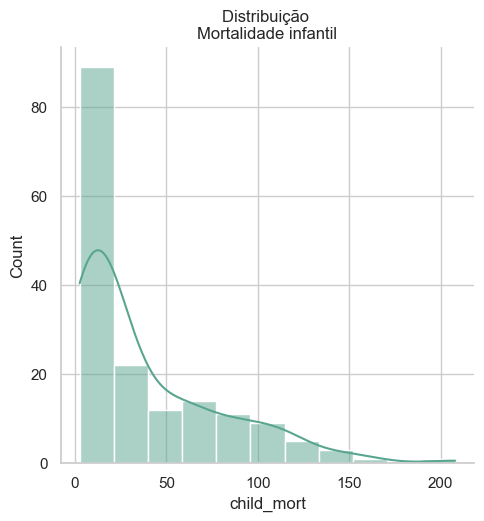

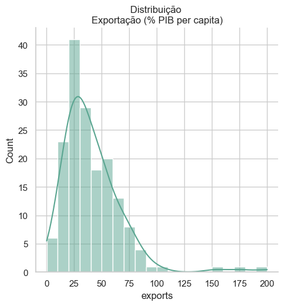

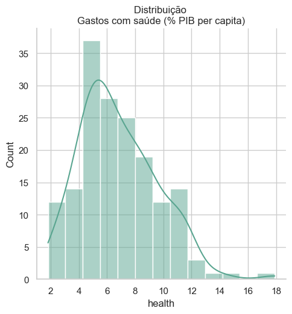

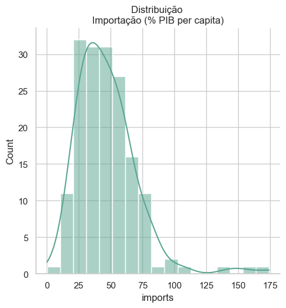

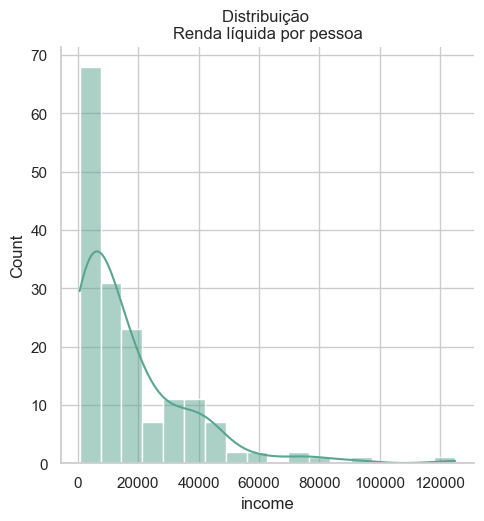

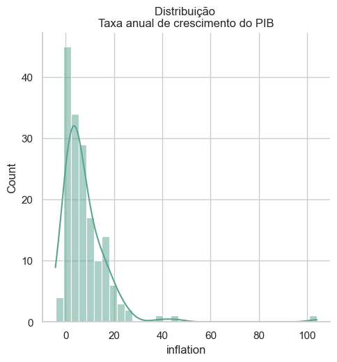

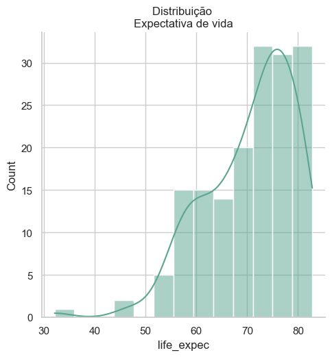

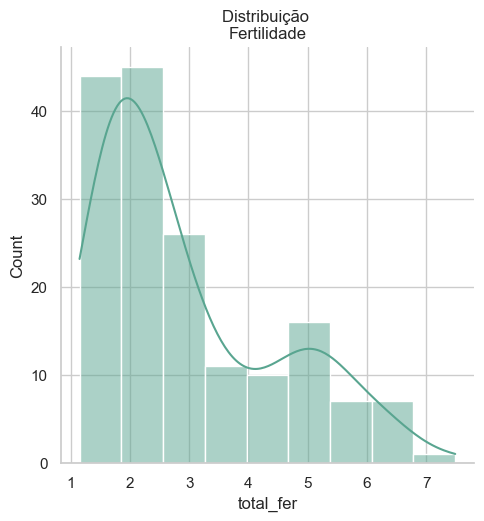

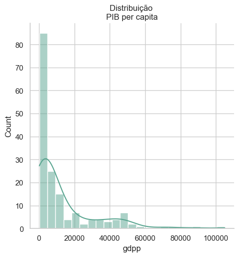

```python
# Distrubuição das features numéricas

for i in range(0, len(indicators_names)):

    sns.displot(data=data, x=indicators_names[i], color='#59A590', kde=True).set(title=f'Distribuição \n{readable_names[i]}')
```

**Realize o pré-processamento adequado dos dados.**

```python
# Normalização dos dados
normalized_data = (economic_indicators - economic_indicators.mean()) / economic_indicators.std()
```

```python
normalized_data.head()
```

| country | child_mort | exports | health | imports | income | inflation | life_expec | total_fer | gdpp |
| --- | --- | --- | --- | --- | --- | --- | --- | --- | --- |
| Afghanistan | 1.287660 | -1.134867 | 0.278251 | -0.082208 | -0.805822 | 0.156864 | -1.614237 | 1.897176 | -0.677143 |
| Albania | -0.537333 | -0.478220 | -0.096725 | 0.070624 | -0.374243 | -0.311411 | 0.645924 | -0.857394 | -0.484167 |
| Algeria | -0.272015 | -0.098824 | -0.963176 | -0.639838 | -0.220182 | 0.786908 | 0.668413 | -0.038289 | -0.463980 |
| Angola | 2.001787 | 0.773056 | -1.443729 | -0.164820 | -0.583289 | 1.382894 | -1.175698 | 2.121770 | -0.514720 |
| Antigua and Barbuda | -0.693548 | 0.160186 | -0.286034 | 0.496076 | 0.101427 | -0.599944 | 0.702147 | -0.540321 | -0.041692 |

## **Etapa - Clusterização**

Realizar o agrupamento dos países em 3 grupos distintos. Para tal, use:

- K-Médias
- Clusterização Hierárquica

Para os resultados, do K-Médias:

- Interprete cada um dos clusters obtidos citando:
  - Qual a distribuição das dimensões em cada grupo
  - O país, de acordo com o algoritmo, melhor representa o seu agrupamento. Justifique
- Para os resultados da Clusterização Hierárquica, apresente o dendograma e interprete os resultados
- Compare os dois resultados, aponte as semelhanças e diferenças e interprete.

### K-Médias

k = 3

```python
kmeans = KMeans(n_clusters=3, random_state=42)
k_fit = kmeans.fit(normalized_data)
```

```python
clusters = k_fit.labels_
clusters
```

```
array([1, 2, 2, 1, 2, 2, 2, 0, 0, 2, 2, 0, 2, 2, 2, 0, 2, 1, 2, 2, 2, 1,
       2, 0, 2, 1, 1, 2, 1, 0, 2, 1, 1, 2, 2, 2, 1, 1, 1, 2, 1, 2, 0, 0,
       0, 2, 2, 2, 2, 1, 1, 2, 2, 0, 0, 1, 1, 2, 0, 1, 0, 2, 2, 1, 1, 2,
       1, 2, 0, 2, 2, 2, 1, 0, 0, 0, 2, 0, 2, 2, 1, 1, 0, 2, 1, 2, 2, 1,
       1, 2, 2, 0, 2, 1, 1, 2, 2, 1, 0, 1, 2, 2, 2, 2, 2, 2, 1, 2, 1, 2,
       0, 0, 1, 1, 0, 2, 1, 2, 2, 2, 2, 2, 0, 0, 2, 2, 1, 2, 2, 1, 2, 2,
       1, 0, 0, 0, 2, 1, 0, 0, 2, 2, 1, 2, 0, 0, 2, 1, 2, 1, 1, 2, 2, 2,
       2, 1, 2, 0, 0, 0, 2, 2, 2, 2, 2, 1, 1])
```

```python
cluster_data = data.copy()
cluster_data['kmeans_cluster'] = clusters
cluster_data.head()
```

|  | country | child_mort | exports | health | imports | income | inflation | life_expec | total_fer | gdpp | kmeans_cluster |
| --- | --- | --- | --- | --- | --- | --- | --- | --- | --- | --- | --- |
| 0 | Afghanistan | 90.2 | 10.0 | 7.58 | 44.9 | 1610 | 9.44 | 56.2 | 5.82 | 553 | 1 |
| 1 | Albania | 16.6 | 28.0 | 6.55 | 48.6 | 9930 | 4.49 | 76.3 | 1.65 | 4090 | 2 |
| 2 | Algeria | 27.3 | 38.4 | 4.17 | 31.4 | 12900 | 16.10 | 76.5 | 2.89 | 4460 | 2 |
| 3 | Angola | 119.0 | 62.3 | 2.85 | 42.9 | 5900 | 22.40 | 60.1 | 6.16 | 3530 | 1 |
| 4 | Antigua and Barbuda | 10.3 | 45.5 | 6.03 | 58.9 | 19100 | 1.44 | 76.8 | 2.13 | 12200 | 2 |

```python
# Resultados médios por feature para cada cluster
cluster_data.groupby('kmeans_cluster').mean()
```

| kmeans_cluster | child_mort | exports | health | imports | income | inflation | life_expec | total_fer | gdpp |
| --- | --- | --- | --- | --- | --- | --- | --- | --- | --- |
| 0 | 5.000000 | 58.738889 | 8.807778 | 51.491667 | 45672.222222 | 2.671250 | 80.127778 | 1.752778 | 42494.444444 |
| 1 | 92.961702 | 29.151277 | 6.388511 | 42.323404 | 3942.404255 | 12.019681 | 59.187234 | 5.008085 | 1922.382979 |
| 2 | 21.927381 | 40.243917 | 6.200952 | 47.473404 | 12305.595238 | 7.600905 | 72.814286 | 2.307500 | 6486.452381 |

**Distribuição das dimensões em cada cluster**

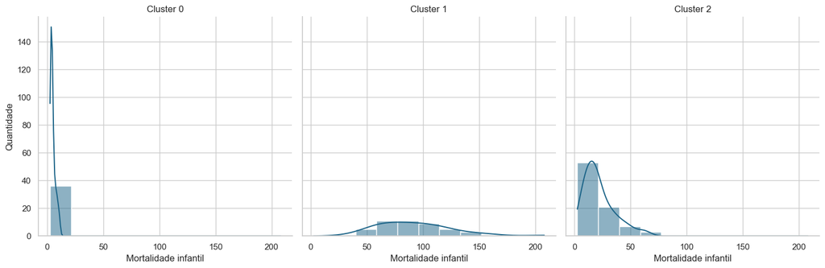

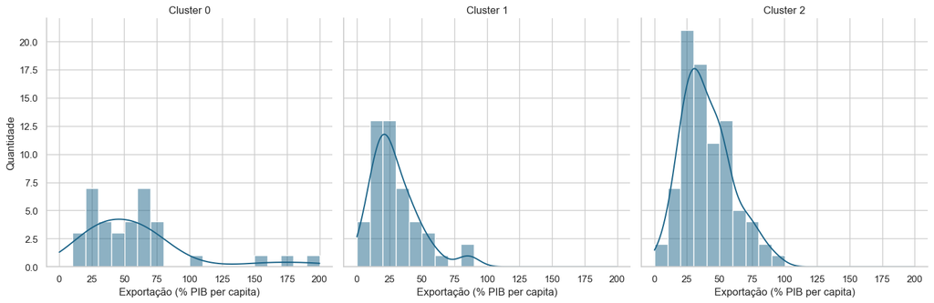

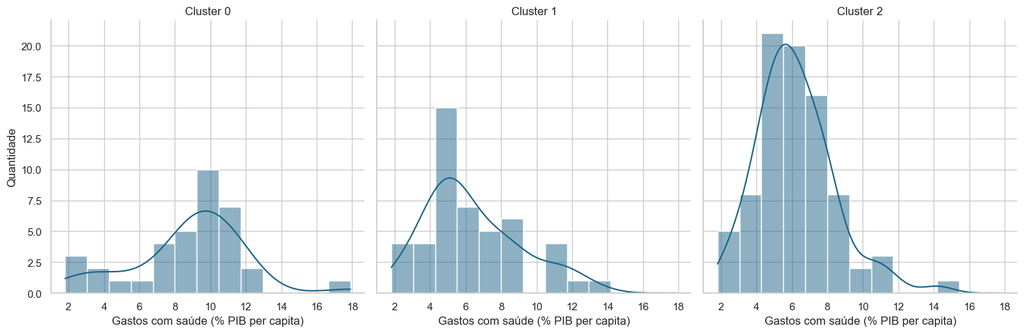

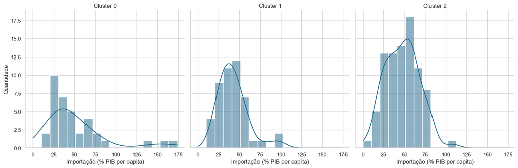

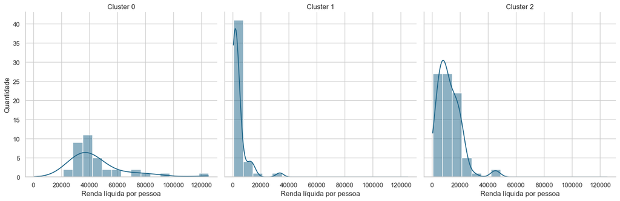

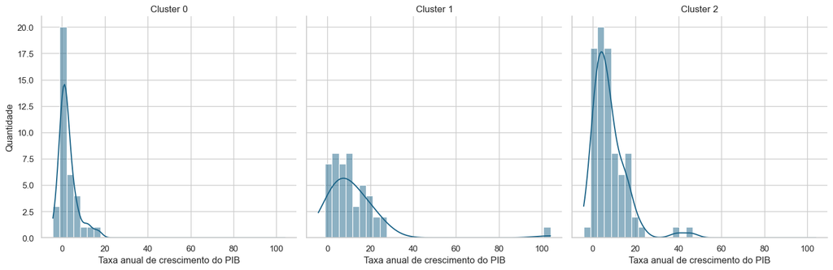

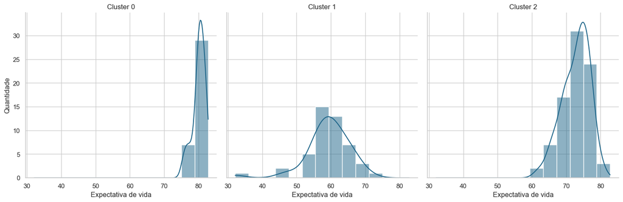

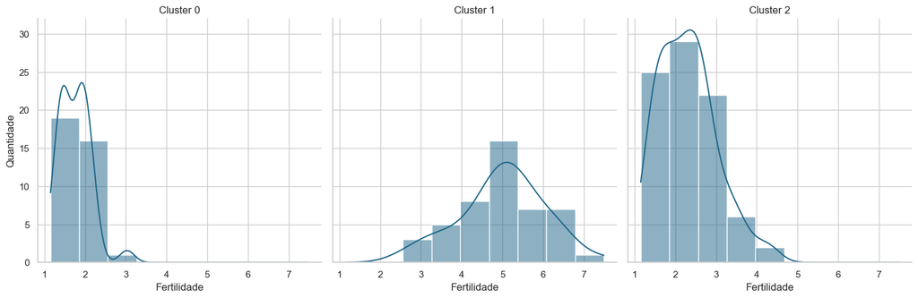

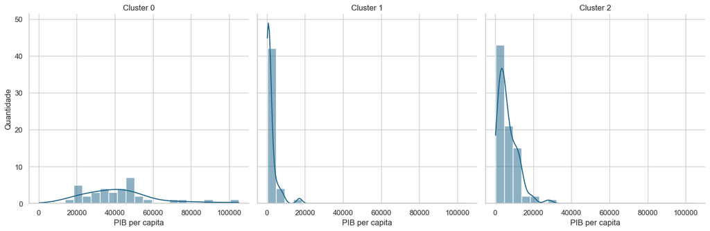

```python
# Distribuição das dimensões por cluster
for i in range(len(indicators_names)):
    g = sns.displot(data=cluster_data, x=indicators_names[i], col='kmeans_cluster', kde=True, color="#1C6488")
    g.set_axis_labels( readable_names[i], 'Quantidade')
    g.set_titles('Cluster {col_name}')
```

**O país, de acordo com o algoritmo, melhor representa o seu agrupamento. Justifique**

```python
# Cópia dos dados normalizados para comparar com os centróides
cluster_normalized_data = normalized_data.copy()
cluster_normalized_data['kmeans_cluster'] = clusters
```

```python
# Obtenção dos centróides dos clusters
k_centers = k_fit.cluster_centers_

centroid_0 = k_centers[0]
centroid_1 = k_centers[1]
centroid_2 = k_centers[2]
```

```python
# Separação dos países em clusters
k_cluster_0 = cluster_normalized_data[cluster_normalized_data['kmeans_cluster'] == 0].drop('kmeans_cluster', axis=1)
k_cluster_1 = cluster_normalized_data[cluster_normalized_data['kmeans_cluster'] == 1].drop('kmeans_cluster', axis=1)
k_cluster_2 = cluster_normalized_data[cluster_normalized_data['kmeans_cluster'] == 2].drop('kmeans_cluster', axis=1)
```

```python
print(f'O tamanho do cluster 0 é {len(k_cluster_0)}.')
print(f'O tamanho do cluster 1 é {len(k_cluster_1)}.')
print(f'O tamanho do cluster 2 é {len(k_cluster_2)}.')
print('\n')
print(f'A soma das amostras dos 3 clusters é {len(k_cluster_0) + len(k_cluster_1) + len(k_cluster_2)}.')
```

```
O tamanho do cluster 0 é 36.
O tamanho do cluster 1 é 47.
O tamanho do cluster 2 é 84.


A soma das amostras dos 3 clusters é 167.
```

```python
# Calcula a distância entre o centróide e os pontos do cluster, retorna o index do cluster com menor distância
idx_min_0, _ = pairwise_distances_argmin_min(centroid_0.reshape(1, -1), Y=k_cluster_0.values,  axis=1, metric='euclidean')
idx_min_1, _ = pairwise_distances_argmin_min(centroid_1.reshape(1, -1), Y=k_cluster_1.values,  axis=1, metric='euclidean')
idx_min_2, _ = pairwise_distances_argmin_min(centroid_1.reshape(1, -1), Y=k_cluster_1.values,  axis=1, metric='euclidean')
```

```python
print('O país que melhor representa um cluster é o que possui features mais próximas do centróide.')
print(f'Para o Cluster 0: {k_cluster_0.iloc[idx_min_0[0]].name}.')
print(f'Para o Cluster 1: {k_cluster_1.iloc[idx_min_1[0]].name}.')
print(f'Para o Cluster 2: {k_cluster_2.iloc[idx_min_2[0]].name}.')
```

[output not shown]

### Clusterização Hierárquica

```python
def plot_dendrogram(model, **kwargs):

    # Children of hierarchical clustering
    children = model.children_

    # Distances between each pair of children
    # Since we don't have this information, we can use a uniform one for plotting
    distance = np.arange(children.shape[0])

    # The number of observations contained in each cluster level
    no_of_observations = np.arange(2, children.shape[0]+2)

    # Create linkage matrix and then plot the dendrogram
    linkage_matrix = np.column_stack([children, distance, no_of_observations]).astype(float)

    # Plot the corresponding dendrogram
    sch.dendrogram(linkage_matrix, **kwargs)
```

```python
model = AgglomerativeClustering(n_clusters=3)
model = model.fit(normalized_data)
```

```python
cluster_data['h_cluster'] = model.labels_
```

```python
cluster_data.head()
```

|  | country | child_mort | exports | health | imports | income | inflation | life_expec | total_fer | gdpp | kmeans_cluster | h_cluster |
| --- | --- | --- | --- | --- | --- | --- | --- | --- | --- | --- | --- | --- |
| 0 | Afghanistan | 90.2 | 10.0 | 7.58 | 44.9 | 1610 | 9.44 | 56.2 | 5.82 | 553 | 1 | 2 |
| 1 | Albania | 16.6 | 28.0 | 6.55 | 48.6 | 9930 | 4.49 | 76.3 | 1.65 | 4090 | 2 | 1 |
| 2 | Algeria | 27.3 | 38.4 | 4.17 | 31.4 | 12900 | 16.10 | 76.5 | 2.89 | 4460 | 2 | 1 |
| 3 | Angola | 119.0 | 62.3 | 2.85 | 42.9 | 5900 | 22.40 | 60.1 | 6.16 | 3530 | 1 | 1 |
| 4 | Antigua and Barbuda | 10.3 | 45.5 | 6.03 | 58.9 | 19100 | 1.44 | 76.8 | 2.13 | 12200 | 2 | 1 |

```python
cluster_data.drop('kmeans_cluster', axis=1).groupby('h_cluster').mean()
```

| h_cluster | child_mort | exports | health | imports | income | inflation | life_expec | total_fer | gdpp |
| --- | --- | --- | --- | --- | --- | --- | --- | --- | --- |
| 0 | 5.961765 | 58.508824 | 8.501176 | 48.902941 | 47588.235294 | 4.115500 | 79.982353 | 1.888529 | 43170.588235 |
| 1 | 31.617925 | 39.990368 | 6.353679 | 48.085527 | 11341.886792 | 9.120604 | 70.921698 | 2.654623 | 6407.367925 |
| 2 | 105.070370 | 23.589630 | 6.507037 | 39.662963 | 1589.740741 | 7.142778 | 57.248148 | 5.433704 | 667.888889 |

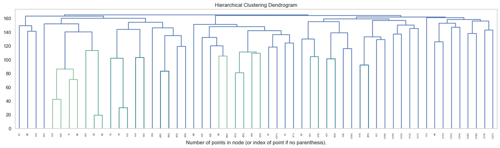

```python
plt.figure(figsize=(20, 5))
plt.grid(False)

plot_dendrogram(model, truncate_mode='level', p=6)
plt.title("Hierarchical Clustering Dendrogram")
plt.xlabel('Number of points in node (or index of point if no parenthesis).')
plt.show()
```

Cruzando uma linha na horizontal na distância de 160, aproximadamente, a base de dados seria categorizada em 4 clusters bem definidos.

Quando o algoritmo de clusterização aglomerativa não recebe o número de clusters, o mesmo identifica que cada linha de dado da base representa um cluster.

**Distribuição das dimensões em cada cluster - HCluster**

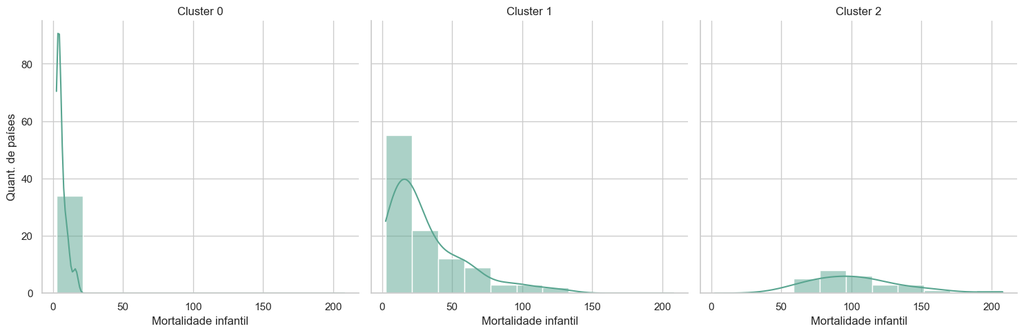

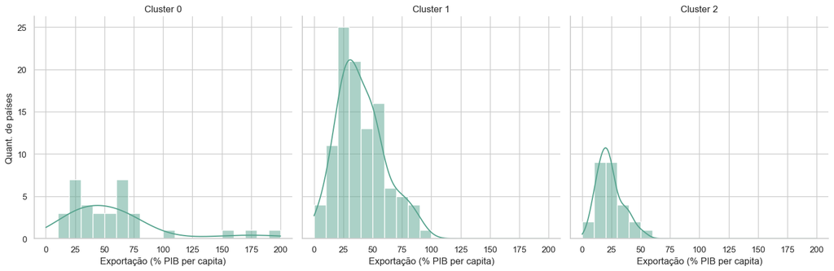

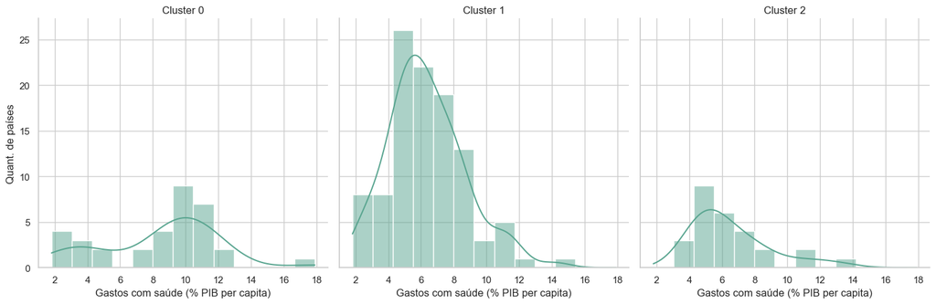

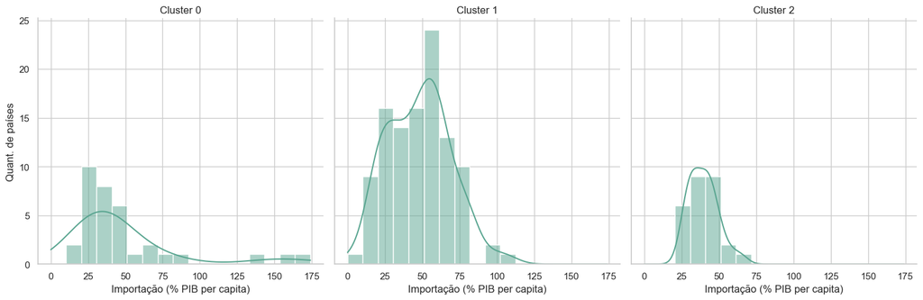

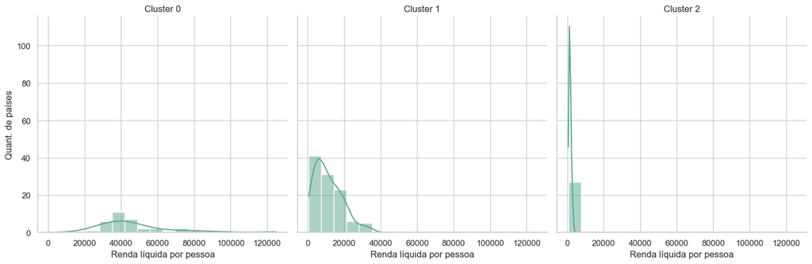

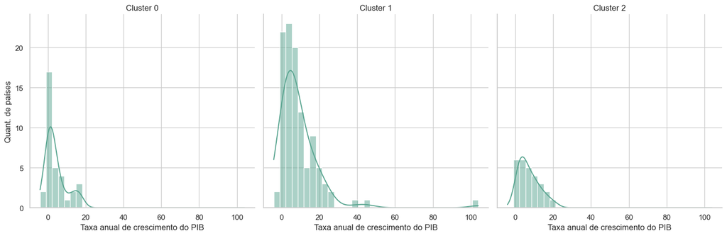

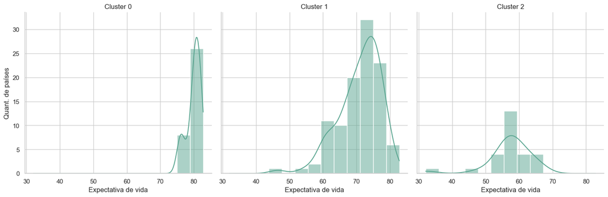

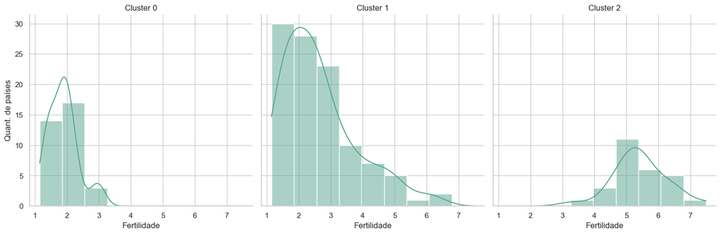

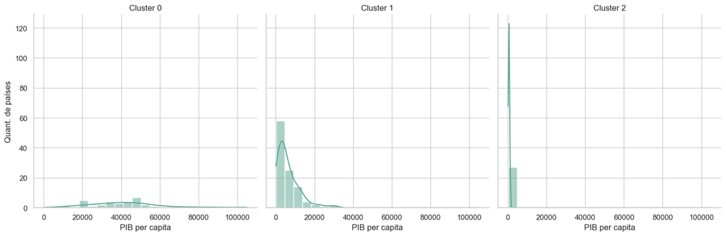

```python
for i in range(len(indicators_names)):
    g = sns.displot(data=cluster_data, x=indicators_names[i], col='h_cluster', kde=True, color="#59A590")
    g.set_axis_labels( readable_names[i], 'Quant. de países')
    g.set_titles('Cluster {col_name}')
```

## **Comparação de resultados**

```python
results = cluster_data.set_index('country')[['kmeans_cluster', 'h_cluster']]
```

```python
results.head()
```

| country | kmeans_cluster | h_cluster |
| --- | --- | --- |
| Afghanistan | 1 | 2 |
| Albania | 2 | 1 |
| Algeria | 2 | 1 |
| Angola | 1 | 1 |
| Antigua and Barbuda | 2 | 1 |

Para a K-Means, tivemos os seguintes resultados médios de cada dimensão por cluster:

```python
cluster_data.drop('h_cluster', axis=1).groupby('kmeans_cluster').mean()
```

| kmeans_cluster | child_mort | exports | health | imports | income | inflation | life_expec | total_fer | gdpp |
| --- | --- | --- | --- | --- | --- | --- | --- | --- | --- |
| 0 | 5.000000 | 58.738889 | 8.807778 | 51.491667 | 45672.222222 | 2.671250 | 80.127778 | 1.752778 | 42494.444444 |
| 1 | 92.961702 | 29.151277 | 6.388511 | 42.323404 | 3942.404255 | 12.019681 | 59.187234 | 5.008085 | 1922.382979 |
| 2 | 21.927381 | 40.243917 | 6.200952 | 47.473404 | 12305.595238 | 7.600905 | 72.814286 | 2.307500 | 6486.452381 |

Para a clusterização hierárquica, tivemos os seguintes resultados médios de cada dimensão por cluster:

```python
cluster_data.drop('kmeans_cluster', axis=1).groupby('h_cluster').mean()
```

| h_cluster | child_mort | exports | health | imports | income | inflation | life_expec | total_fer | gdpp |
| --- | --- | --- | --- | --- | --- | --- | --- | --- | --- |
| 0 | 5.961765 | 58.508824 | 8.501176 | 48.902941 | 47588.235294 | 4.115500 | 79.982353 | 1.888529 | 43170.588235 |
| 1 | 31.617925 | 39.990368 | 6.353679 | 48.085527 | 11341.886792 | 9.120604 | 70.921698 | 2.654623 | 6407.367925 |
| 2 | 105.070370 | 23.589630 | 6.507037 | 39.662963 | 1589.740741 | 7.142778 | 57.248148 | 5.433704 | 667.888889 |

### **Clusterização por K-Médias - Avaliação dos clusters**

#### Cluster 0

- Menor mortalidade infantil
- O percentual do PIB per capita em exportação varia bastante, além de apontar alguns outliers na distribuição
- O percentual do PIB de gastos com a saúde mais comum é de 10%
- O percentual do PIB em importação mais comum é de 25%, além disso também apresenta outliers na distribuição
- A renda líquida por pessoa varia um pouco, mas sua maior concentração é entre 30 e 50 mil
- A taxa anual de crescimento do PIB é baixa
- A expectativa de vida é alta
- As mulheres costumam ter 1 ou 2 filhos
- O PIB per capita possui uma distribuição não muito ilustrativa, visto que possui valores muito distribuídos em todo o eixo x

#### Cluster 1

- A mortalidade infantil é mais alta quando comparada ao cluster 0
- O percental do PIB em exportação consiste em até 50%, em média
- Os gastos com saúde variam mais, sendo o mais comum o gasto de 5% do PIB
- O percentual de importação mais comum aumenta, em relação ao cluster anterior
- A renda líquida por pessoa é baixíssima, demonstrando uma menor condição de lidar com imprevistos
- Apesar disto, a taxa de crescimento anual do PIB é maior do que o cluster anterior, porém menos previsível. Além disso, um país que não se adequa ao cluster aparenta ter sido classificado no mesmo, visto o aparecimento de 1 bin na taxa de valor 100
- A expectativa de vida varia bastante
- Uma mulher em idade fértil deve ter entre 3 e 7 filhos, sendo o mais comum, 5 filhos
- O PIB per capita dos países é baixo

#### Cluster 2

- A mortalidade infantil em geral é baixa, mas possui alguns países com mortalidade elevada
- Grande parte dos países possui grande parte do % do PIB em exportação
- Os gastos com saúde representam em média 5% do PIB per capita
- Grande parte dos países possui por volta de 55% do percentual do PIB per capita em importação
- A renda líquida por pessoa não é tão baixa quanto no cluster anterior
- A taxa anual de crescimento do PIB varia bastante
- Os países apresentam alta expectativa de vida
- É mais comum que as mulheres tenham de 1 a 3 filhos
- o PIB per capita é parecido com o cluster anterior, concentrado em valores baixos

## **Etapa - Escolha de algoritmos**

**1. Escreva em tópicos as etapas do algoritmo de K-médias até sua convergência.**

1. Inicializar k centróides em pontos aleatórios
2. Para cada ponto, encontrar qual o centróide mais próximo
3. Calcular o baricentro dos pontos para cada centróide
4. Mover o centróide na direção do seu baricentro
5. Repetir a partir de 2.

A convergência ocorre quando o movimento for menor que um valor pré-definido ou quando o número de iterações pré-especificado for atingido

**2. O algoritmo de K-médias converge até encontrar os centróides que melhor descrevem os clusters encontrados (até o deslocamento entre as interações dos centróides ser mínimo). Lembrando que o centróide é o baricentro do cluster em questão e não representa, em via de regra, um dado existente na base. Refaça o algoritmo apresentado na questão 1 a fim de garantir que o cluster seja representado pelo dado mais próximo ao seu baricentro em todas as iterações do algoritmo.**

Obs: nesse novo algoritmo, o dado escolhido será chamado medóide.

R: O ponto que descreve o cluster é um ponto que pertence ao cluster. O que melhor representa o agrupamento, é o país mais próximo ao centróide.

1. Selecionar k pontos aleatórios no conjunto de dados e definir como medóides.
2. Calcular a matriz de dissimilaridade.
3. Atribuir cada ponto ao seu medóide mais próximo.
4. Para cada cluster, verificar se existe algum ponto mais central do que o medóide inicialmente escolhido.
5. Repetir do passo 3 em diante até a convergência.

**3. O algoritmo de K-médias é sensível a outliers nos dados. Explique.**

Como o K-Means é baseado na medida de tendência central média, o mesmo é extremamente sensível a outliers visto que a média é deslocada na presenta deles. Caso a medida de tendência central fosse a mediana, o algoritmo seria menos sensível a outliers.

**4. Por que o algoritmo de DBScan é mais robusto à presença de outliers?**

Porque a sua avaliação agrupa pontos próximos e os difere de ruídos, fazendo com que a inclusão de um outlier dentro de um cluster ocorra durante na definição de parâmetros errados, sendo mais provável que este outlier seja classificado como ruído.